# JACIE Autologous Transplant Outcomes Report

2024-2025 Annual Report - Rolling Cohort Analysis

Author

HSCT Program Quality Indicators

Published

January 27, 2026

# Executive Summary

## Reporting Period and Methodology

**Reporting Period:** Calendar Years 2024 and 2025

**Methodology:** Cumulative Rolling Cohort Analysis following JACIE Italian guidelines

**ImportantCumulative Rolling Cohort Methodology**

This report uses **cumulative rolling cohort analysis** as specified by JACIE Italy. For each timepoint, we calculate outcomes for patients who reached that milestone during the specified reporting period.

**Key principle**: Patients are selected based on when they **reached** each milestone (100 days or 365 days post-transplant), not just when they were transplanted.

**Cohort Selection:**

- **100-day outcome**: Patients whose 100-day milestone fell within the reporting period
- **365-day outcome**: Patients whose 365-day milestone fell within the reporting period

This ensures adequate follow-up time for each patient included in the analysis.

## Key Findings Summary

### 2025 Autologous Transplant Outcomes

Table 1: 2025 Autologous Transplant Outcomes - Rolling Cohort Analysis

| Endpoint | Timepoint | Cohort Size | Events | Rate |
| --- | --- | --- | --- | --- |
| **Overall Survival** |  |  |  |  |
| Overall Survival (OS) | 100 days | 49 | 1 | 98% |
| Overall Survival (OS) | 365 days | 32 | 2 | 93.8% |
| **Treatment-Related Mortality** |  |  |  |  |
| Treatment-Related Mortality (TRM) | 100 days | 49 | 1 | 2% |
| Treatment-Related Mortality (TRM) | 365 days | 32 | 1 | 3.1% |

**Tip2025 Outcomes Highlights**

**Overall Survival:**

- **100-day OS**: 98% (48/49 patients alive)
- **365-day OS**: 93.8% (30/32 patients alive)

**Treatment-Related Mortality:**

- **100-day TRM**: 2% (1/49 patients)
- **365-day TRM**: 3.1% (1/32 patients)

# Detailed Results

## 1. Cohort Description

### 1.1 Patient Population

Table 2: Patient Population Overview

| Category | N |
| --- | --- |
| Total patients in database | 69 |
| Lost to follow-up | 1 |
| Evaluable patients | 68 |
| 2024 transplants | 32 |
| 2025 transplants | 36 |

**WarningLost to Follow-up**

**1 patient** was lost to follow-up and excluded from the analysis:

| Patient | Diagnosis | HSCT Date |
| --- | --- | --- |
| Rapuano Giuseppe | LNH | 2024-07-08 |

### 1.2 Age at Transplant

Table 3: Age at Transplant

| Statistic | Value |
| --- | --- |
| Mean (SD) | 58.3 years (SD: 10.6) |
| Median | 62.1 years |
| Range | 18.0 - 71.7 years |

### 1.3 Follow-up Duration

Table 4: Follow-up Duration

| Statistic | Days | Months |
| --- | --- | --- |
| Mean | 349.6 days | 11.5 months |
| Median | 350 days | 11.5 months |
| Range | 9 - 723 days | 0.3 - 23.8 months |

### 1.4 Diagnosis Distribution

Table 5: Diagnosis Distribution

| Diagnosis | N | Percentage |
| --- | --- | --- |
| Multiple Myeloma (MM) | 54 | 79.4% |
| Non-Hodgkin Lymphoma (NHL) | 8 | 11.8% |
| Hodgkin Lymphoma (HL) | 6 | 8.8% |

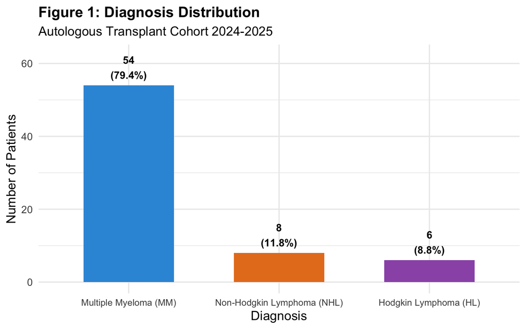

### 1.5 Transplant Year Distribution

Table 6: Transplant Year Distribution

| Year | N | Percentage |
| --- | --- | --- |
| 2024 | 32 | 47.1% |
| 2025 | 36 | 52.9% |

## 2. Overall Survival (OS)

### 2.1 OS - 2025 Analysis

Table 7: Overall Survival - 2025 Rolling Cohort

| Timepoint | Cohort Size | Deaths | Alive (n) | OS Rate | Mortality Rate |
| --- | --- | --- | --- | --- | --- |
| 100 days | 49 | 1 | 48 | 98% | 2% |
| 365 days | 32 | 2 | 30 | 93.8% | 6.2% |

### 2.2 OS - 2024 Analysis

Table 8: Overall Survival - 2024 Rolling Cohort

| Timepoint | Cohort Size | Deaths | Alive (n) | OS Rate | Mortality Rate |
| --- | --- | --- | --- | --- | --- |
| 100 days | 12 | 0 | 12 | 100% | 0% |
| 365 days | 0 | NA | NA | N/A* | N/A* |

**NoteNote on 2024 365-Day Analysis**

*N/A: No patients transplanted in 2024 had reached their 365-day milestone within the 2024 reporting period (milestone dates: Jan 1, 2023 - Dec 31, 2024). These patients are captured in the 2025 rolling cohort analysis.

## 3. Treatment-Related Mortality (TRM)

### 3.1 TRM - 2025 Analysis

Table 9: Treatment-Related Mortality - 2025 Rolling Cohort

| Timepoint | Cohort Size | TRM Deaths | TRM Rate | n/N (%) |
| --- | --- | --- | --- | --- |
| 100 days | 49 | 1 | 2% | 1/49 (2%) |
| 365 days | 32 | 1 | 3.1% | 1/32 (3.1%) |

### 3.2 TRM - 2024 Analysis

Table 10: Treatment-Related Mortality - 2024 Rolling Cohort

| Timepoint | Cohort Size | TRM Deaths | TRM Rate | n/N (%) |
| --- | --- | --- | --- | --- |
| 100 days | 12 | 0 | 0% | 0/12 (0%) |
| 365 days | 0 | NA | N/A* | N/A* |

### 3.3 Death Details

Table 11: Details of Deceased Patients

| Patient | Diagnosis | HSCT Date | Days to Death | TRM |
| --- | --- | --- | --- | --- |
| De Lazzari Adriano | Multiple Myeloma (MM) | July 03, 2024 | 364 | No |
| Mares Henoch Sigisfredo | Multiple Myeloma (MM) | December 02, 2024 | 9 | Yes |

**ImportantDeath Summary**

**Total deaths:** 2

**Death classification:**

- TRM deaths: 1
- Non-TRM deaths (NRM): 1

**Individual patient details:**

- **De Lazzari Adriano**: Day 364 death (NRM)
- **Mares Henoch Sigisfredo**: Day 9 death (TRM)

## 4. JACIE Comparison: 2024 vs 2025

Table 12: JACIE Comparison - 2024 vs 2025 Autologous Transplant Outcomes

| Year | Endpoint | Timepoint | Cohort Size | Events | Rate |
| --- | --- | --- | --- | --- | --- |
| **2024** |  |  |  |  |  |
| 2024 | OS | 100 days | 12 | 0 | 100% |
| 2024 | OS | 365 days | 0 | NA | N/A* |
| 2024 | TRM | 100 days | 12 | 0 | 0% |
| 2024 | TRM | 365 days | 0 | NA | N/A* |
| **2025** |  |  |  |  |  |
| 2025 | OS | 100 days | 49 | 1 | 98% |
| 2025 | OS | 365 days | 32 | 2 | 93.8% |
| 2025 | TRM | 100 days | 49 | 1 | 2% |
| 2025 | TRM | 365 days | 32 | 1 | 3.1% |

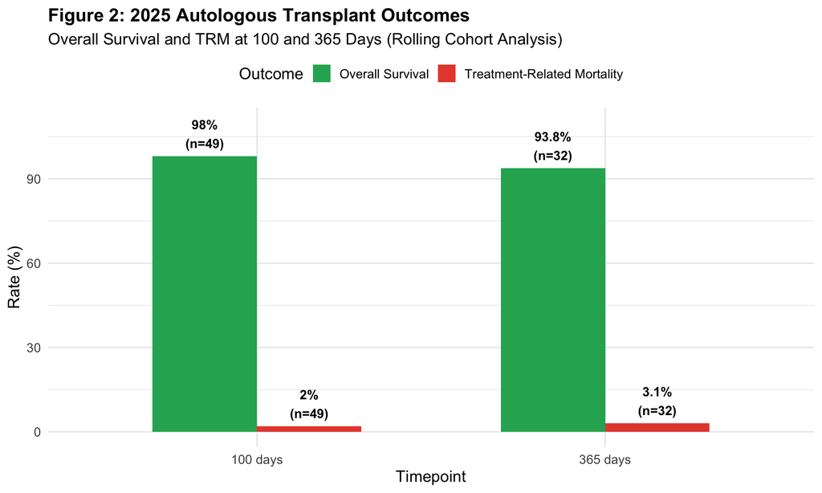

# Methodology

## Cumulative Rolling Cohort Breakdown

The following table shows the detailed breakdown of each rolling cohort used in the analysis, including the number of patients selected and the time periods used for selection.

Table 13: Cumulative Rolling Cohort Breakdown - Patients and Time Periods

| Year | Timepoint | Milestone Date Range | HSCT Date Range | Patients Selected | Deaths | TRM Deaths |
| --- | --- | --- | --- | --- | --- | --- |
| **2024 Analysis** |  |  |  |  |  |  |
| 2024 | 100 days | Jul 1, 2023 - Sep 30, 2024 | Mar 23, 2023 - Jun 22, 2024 | 12 | 0 | 0 |
| 2024 | 365 days | Jan 1, 2023 - Dec 31, 2024 | Jan 1, 2022 - Dec 31, 2023 | 0 | NA | NA |
| **2025 Analysis** |  |  |  |  |  |  |
| 2025 | 100 days | Jul 1, 2024 - Sep 30, 2025 | Mar 23, 2024 - Jun 22, 2025 | 49 | 1 | 1 |
| 2025 | 365 days | Jan 1, 2024 - Dec 31, 2025 | Jan 1, 2023 - Dec 31, 2024 | 32 | 2 | 1 |

**NoteUnderstanding the Cohort Selection**

**How patients are selected:**

- For **100-day analysis**: Patients whose 100-day post-HSCT milestone (HSCT date + 100 days) falls within the milestone date range
- For **365-day analysis**: Patients whose 365-day post-HSCT milestone (HSCT date + 365 days) falls within the milestone date range

**Example for 2025 100-day cohort:**

- Milestone period: Jul 1, 2024 - Sep 30, 2025
- This includes patients transplanted approximately Mar 23, 2024 - Jun 22, 2025
- **49 patients** met these criteria

**Note:** The 2024 365-day cohort has 0 patients because no patients transplanted in the required period (2022-2023) had their 365-day milestone fall within the 2024 reporting window.

## Rolling Cohort Selection Criteria

Table 14: Rolling Cohort Selection Methodology

| Timepoint | Milestone Period (2025) | Milestone Period (2024) | Explanation |
| --- | --- | --- | --- |
| 100 days | Jul 1, 2024 - Sep 30, 2025 | Jul 1, 2023 - Sep 30, 2024 | Patients whose 100-day post-HSCT milestone fell within this period |
| 365 days | Jan 1, 2024 - Dec 31, 2025 | Jan 1, 2023 - Dec 31, 2024 | Patients whose 365-day post-HSCT milestone fell within this period |

## Key Definitions

**Overall Survival (OS)**: Percentage of patients alive at the specified timepoint. Calculated as:
$$OS = \frac{\text{Patients Alive at Timepoint}}{\text{Total Patients in Cohort}} \times 100\%$$

**Treatment-Related Mortality (TRM)**: Deaths directly attributed to the transplant procedure and its complications (not disease progression). Calculated as:
$$TRM = \frac{\text{TRM Deaths at Timepoint}}{\text{Total Patients in Cohort}} \times 100\%$$

# Conclusions

## Key Findings

### 2025 Autologous Transplant Program Performance

1. **Overall Survival**
   - 100-day OS: **98%** (48/49 patients)
   - 365-day OS: **93.8%** (30/32 patients)
2. **Treatment-Related Mortality**
   - 100-day TRM: **2%** (1 events)
   - 365-day TRM: **3.1%** (1 events)
3. **Cohort Characteristics**
   - Total evaluable patients: **68**
   - Mean age: **58.3 years**
   - Mean follow-up: **349.6 days** (11.5 months)
   - Primary indication: **Multiple Myeloma** (79.4%)
4. **Data Quality Note**
   - 1 patient (Rapuano Giuseppe) was lost to follow-up and excluded from analysis

*Report generated January 27, 2026 using cumulative rolling cohort methodology per JACIE Italian guidelines*

*OS = Overall Survival; TRM = Treatment-Related Mortality*